# Training data

Practical Machine Learning - Course Project - Salvino A. Salvaggio - July 2014

### Executive Summary

Removing several variables which are empty or NAs reduced the original data set from 160 to 53 variables (52 predictors + variable ‘classe’ as outcome). A sampled subset (40% out of 19622 observations) of the reduced data set was then partioned in 2 equal parts for **training** and **validation**. Five (5) machine learning algorithms were run on the training set and accuracy measured, then the models were applied to the validation data set. In-sample and out-sample errors rates indicate that random forest algorithm is the most accurate in predicting. Finally, **the RF model was applied to the 20-case test data set and accurately predicted all the cases**.

### Background

Using devices such as Jawbone Up, Nike FuelBand, and Fitbit it is now possible to collect a large amount of data about personal activity relatively inexpensively. These type of devices are part of the quantified self movement – a group of enthusiasts who take measurements about themselves regularly to improve their health, to find patterns in their behavior, or because they are tech geeks. One thing that people regularly do is quantify how much of a particular activity they do, but they rarely quantify how well they do it.

- More information is available from the website [here] (http://groupware.les.inf.puc-rio.br/har) (see the section on the Weight Lifting Exercise Dataset)
- The training data for this project are available [here] (https://d396qusza40orc.cloudfront.net/predmachlearn/pml-training.csv).
- The test data are available [here] (https://d396qusza40orc.cloudfront.net/predmachlearn/pml-testing.csv).
- The data for this project come from this [source] (http://groupware.les.inf.puc-rio.br/har).

### Load files and preprocess data

```r
# load library doMC that will force R to use all cores of Mac in parallel
library('doMC')
registerDoMC(cores = 2)
set.seed(3846)
test <- data.frame(read.csv('pml-testing.csv', header = T))
data <- data.frame(read.csv('pml-training.csv', header = T))
dim(data)
str(data)
head(data)
```

Many variables in the original data set are mostly populated with NAs or left empty. Removing them will not impact much machine learning algorithms.

```r
library('plyr') ; library('caret')
# populate empty cells with NAs
data[data == ''] <- NA
# define function to count NAs
nmissing <- function(x) sum(is.na(x))
# use colwise from plyr package to apply the function to columns
missingNA <- colwise(nmissing)(data)
# identify columns that have more than 50% NAs
indexMissingNA <- missingNA >= dim(data)[1]/2
# clean data base on such index
data <- data[, !indexMissingNA]
# manually remove user_name, timestamps
data <- data[, -(1:7)]
```

The outcome of this initial cleaning is a data set reduced from 160 to 53 variables (52 predictors and the variable ‘classe’). Reasons for removing the variables: * many variables are empty or populated with NAs * I decided to remove all variables which are not the outcome of a sensor (timestamps, user name) * ‘window’ variables are also removed, for they seem to mimic the behavior of the ‘classe’ variable (almost full correlation)

### Data Partition

The rationale behind the partition of the original data is as follows:

- A 20-case test set is already provided, there therefore is no need to generate a new test set
- The original training data set counts more than 19,000 observations –which is more than sufficient to train and validate the ML algorithms. Fourty percent of the observations will be randomly selected for that purpose
- this 40% subset will then be split in 2 equal parts for training and validation. Each of these subset will therefore count 20% of the original data set

```r
# sample half of original observations
sample <- data[sample(nrow(data), dim(data)[1]*0.4, replace=FALSE), ]

# create training and validation subsets
indexSample <- createDataPartition(y=sample$classe, p=.5, list=FALSE)
training <- sample[indexSample,]
validation <- sample[-indexSample,]
```

#### Identify and plot the most correlated variables

As part of the initial data exploration this code identifies and plots the variables which have at least 0.9 correlation.

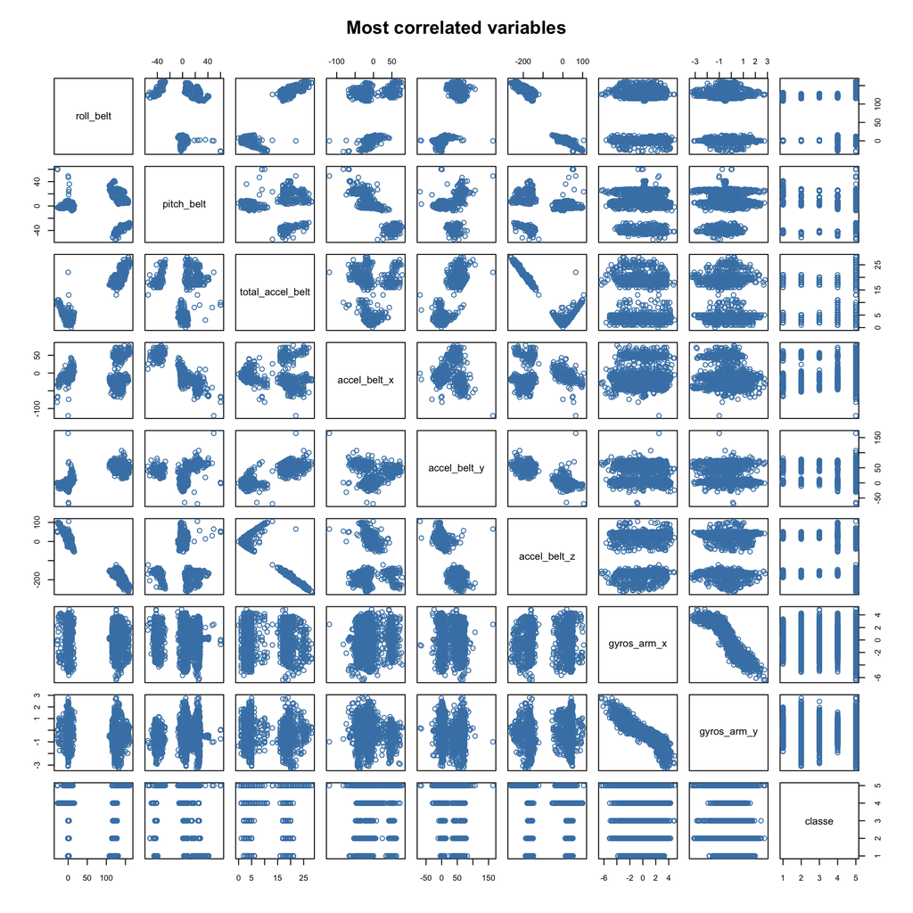

```r
# list the variables which are strongly correlated
M <- abs(cor(training[,-53]))
diag(M) <- 0
strongCor <- which(M >= 0.9, arr.ind=TRUE)
strongCorVariables <- sort(unique(strongCor[,1]))
numStrongCor <- length(strongCorVariables)
correlated <- training[, c(strongCorVariables, 53)]
par(mar=c(2,2,2,2), cex.axis=0.8)
pairs(correlated, main='Most correlated variables', col='steelblue')
```

### Machine learning

In this chapter we will:

1. run several ML algorithms (training)
2. validate models by predicting values in validation data set, then compare accuracy, in-sample and out-sample error rates

#### ML models

Several tests showed that, in my case, time of calculation increases only by a couple of minutes when including all the 52 predictors instead of focusing on highly correlated variables only (MacBookPro 2014, 16GB RAM). However, whit a limited number of variables the accuracy of final testing drops. That is why, I have decided to run the ML models on all the predictors (52 variables)

```r
library('randomForest')
# 1- Trees (rpart method)
fitTREE <- train(classe ~ ., data=training, method='rpart', preProcess=c("center", "scale"))

# 2- Random Forest
fitControlRF <- trainControl(method = "cv", number = 5)
fitRF <- train(classe ~ ., data=training, method='rf', preProcess=c("center", "scale"),
               trControl = fitControlRF, prox=TRUE, verbose = FALSE)

# 3- GBM
fitControl <- trainControl(method = "repeatedcv", number = 10, repeats = 10)
fitGBM <- train(classe ~ ., data = training, method = 'gbm', trControl = fitControl,
                verbose = FALSE)

# 4- Support Vector Machine (SVM)
fitSVM <- train(classe ~., data=training, method = 'svmLinear', trControl = fitControl)

# 5- Principal Components Analysis (PCA)
strongCorPCA <- which(M >= 0.7, arr.ind=TRUE)
strongCorVariablesPCA <- sort(unique(strongCorPCA[,1]))
numStrongCorPCA <- length(strongCorVariablesPCA)
correlatedPCA <- training[, c(strongCorVariablesPCA, 53)]
fitPCA <- train(correlatedPCA$classe ~ ., method='glmnet', preProcess='pca',
                data=correlatedPCA)
```

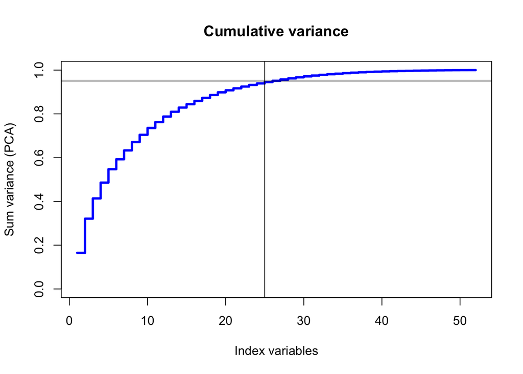

```r
PCAanalysis <- prcomp(training[,-dim(training)[2]], scale. = TRUE)
varianceVector <- PCAanalysis$sdev ^ 2
relativeVariance <- varianceVector / sum(varianceVector)
cumulativeVariance <- cumsum(relativeVariance)
plot(cumulativeVariance, type='s', main='Cumulative variance',
     ylab='Sum variance (PCA)', xlab='Index variables', ylim=c(0,1), col='blue',
     lwd=3)
abline(v=25)
abline(h=0.95)
```

#### Errors and validation

```r
method <- c('trees', 'RF', 'GBM', 'SVM', 'PCA')

# in-sample error
inSample.Accuracy <- c(max(fitTREE$results[,2]),
                       max(fitRF$results[,2]),
                       max(fitGBM$results[,4]),
                       max(fitSVM$results[,2]),
                       max(fitPCA$results[,3])
                       )
inSample.Error <- c(1 - max(fitTREE$results[,2]),
                    1 - max(fitRF$results[,2]),
                    1 - max(fitGBM$results[,4]),
                    1 - max(fitSVM$results[,2]),
                    1 - max(fitPCA$results[,3])
                    )

# TREE prediction on validation set
predictedValuesTREE <- predict(fitTREE, validation)
confM.TREE <- confusionMatrix(validation$classe, predictedValuesTREE)

# RF prediction on validation set
predictedValuesRF <- predict(fitRF, validation)
confM.RF <- confusionMatrix(validation$classe, predictedValuesRF)

# GBM prediction on validation set
predictedValuesGBM <- predict(fitGBM, validation)
confM.GBM <- confusionMatrix(validation$classe, predictedValuesGBM)

# SVM prediction on validation set
predictedValuesSVM <- predict(fitSVM, validation)
confM.SVM <- confusionMatrix(validation$classe, predictedValuesSVM)

# PCA prediction on validation set
predictedValuesPCA <- predict(fitPCA, validation)
confM.PCA <- confusionMatrix(validation$classe, predictedValuesPCA)

outSample.Accuracy <- c(as.numeric(confM.TREE$overall[1]),
                        as.numeric(confM.RF$overall[1]),
                        as.numeric(confM.GBM$overall[1]),
                        as.numeric(confM.SVM$overall[1]),
                        as.numeric(confM.PCA$overall[1])
                        )
outSample.Error <- c(1 - as.numeric(confM.TREE$overall[1]),
                     1 - as.numeric(confM.RF$overall[1]),
                     1 - as.numeric(confM.GBM$overall[1]),
                     1 - as.numeric(confM.SVM$overall[1]),
                     1 - as.numeric(confM.PCA$overall[1])
                        )
errors.df <- data.frame(method = method,
                        inSample.Acc = inSample.Accuracy,
                        inSample.Err = inSample.Error,
                        outSample.Acc = outSample.Accuracy,
                        outSample.Err = outSample.Error,
                        stringsAsFactors=FALSE)
errors.df
```

```
##   method inSample.Acc inSample.Err outSample.Acc outSample.Err
## 1  trees       0.4869      0.51313        0.4945       0.50548
## 2     RF       0.9631      0.03694        0.9763       0.02371
## 3    GBM       0.9446      0.05544        0.9416       0.05837
## 4    SVM       0.7612      0.23878        0.7660       0.23400
## 5    PCA       0.4479      0.55205        0.4662       0.53378
```

[output not shown]

**Accuracy comparison plot**

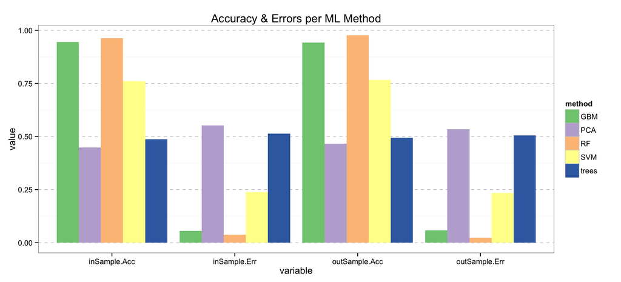

```r
library('reshape2')
meltErrors <- melt(errors.df, id=c('method'))
ggplot(meltErrors, aes(x=variable, y=value, fill=method)) +
    geom_bar(position='dodge', stat='identity') +
    scale_fill_brewer(palette='Accent') +
    ggtitle('Accuracy & Errors per ML Method') +
    theme_bw() +
    theme(panel.grid.major.x = element_blank(),
          panel.grid.minor.x = element_blank(),
          panel.grid.major.y = element_line(colour='grey60',
                                            linetype='dashed'))
```

The random forest algorithm gives the best prediction rate on both the training and the validation data sets. It worths noting that the out-sample accuracy (on validation data set) is higher than the in-sample accuracy (on training data set), which is not common and should raised a flag for more attention.

### Predict test cases

```r
predictedTEST <- predict(fitRF, test)
predictedTEST
```

```
##  [1] B A B A A E D B A A B C B A E E A B B B
## Levels: A B C D E
```

```r
# Save txt files for assignment submission
pml_write_files = function(x){
  n = length(x)
  for(i in 1:n){
    filename = paste0("problem_id_",i,".txt")
    write.table(x[i],file=filename,quote=FALSE,row.names=FALSE,col.names=FALSE)
  }
}
pml_write_files(predictedTEST)
```